# Zadanie 3:

Jakub Anczyk

2022-05-31

#### Analiza dziennych stóp zwrotu i wolumenu transakcyjnego spółek

W tym zadaniu postanowiłem zbadać dzienne stopy zwrotu i wolumen transakcyjny spółek **British Petroleum** (BP), **Cameco** (CCJ) oraz **Northrop Grumman Corporation** (NOC) na Nowojorskiej Giełdzie Papierów Wartościowych. W tym celu wykorzystałem dane z Yahoo Finance za pośrednictwem biblioteki tidyquant.

Wybrałem te trzy spółki, ponieważ reprezentują trzy różne sposoby, w jakie wojna na Ukrainie wpływa na rynek papierów wartościowych.

British Petroleum jest brytyjską spółką z siedzibą w Londynie i trzecim co do wielkości przedsiębiorstwem petrochemicznym na świecie z przychodami na poziomie 246 miliardów dolarów (2021).

Cameco (CCJ) z kolei jest największą na świecie spółką uranową notowaną na giełdzie, posiadającą kopalnie w Kanadzie, Stanach Zjednoczonych i Kazachstanie. W 2015 roku była drugim co do wielkości producentem uranu, odpowiadając za 18% światowej produkcji. Przychoy tej spółki sięgają 2,9 miliardów dolarów (2021).

Northrop Grumman Corporation (NOC) to amerykańską międzynarodowym koncernem z branży lotniczej i kosmonautycznej oraz technologii obronnych. Przychoy tej spółki sięgają 43,5 miliardów dolarów (2021). Jest jednym z największych na świecie producentów broni i dostawców technologii wojskowych.

W celu obliczenia dziennych stóp zwrotu skorzystałem z definicji “overnight return” dla wartości procentowej i walutowej poszczególnych kursów. Zachowanie kursu akcji spółek badałem w okresie poprzedzającym inwazję między dniem 2022-01-24 a 2022-02-23, oraz bezpośrednio po inwazji, między 2022-02-25 a 2022-03-24, z wyłączeniem dnia inwazji przypadającego na 2022-02-24.

#### Analiza statystyk opisowych

[output not shown]

Poniższe zestawienie ukazuje poszczególne rodzaje wykresów analizujące zachowanie kursu akcji badanych spółek:

#### Wykres pudełkowy kursu akcji

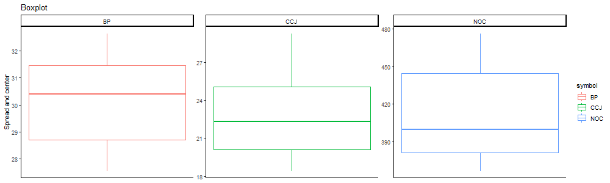

##### Wykres kursu akcji

Wykresy kursu akcji wskazują na wyraźne różnice w dynamice kursu w obu badanych okresach. Odd wybuchu wojny 24 lutego 2022 sółki Northrop Grumman Corporation oraz Cameco zanotowały gwałtowny wzrost, natomiast Brithish Petroleum wyraźny spadek.

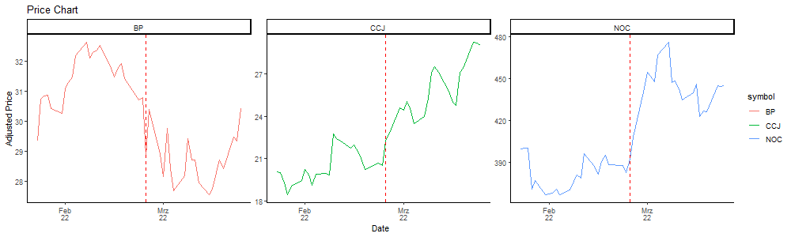

#### Wykres wolumenu transakcyjnego

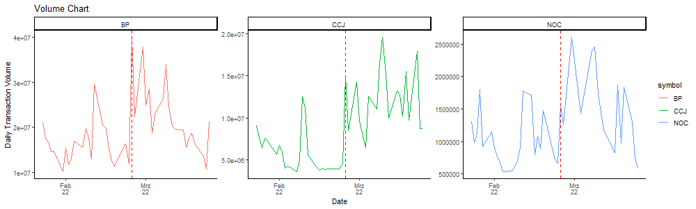

#### Wykres dziennej stopy zwrotu (w dolarach)

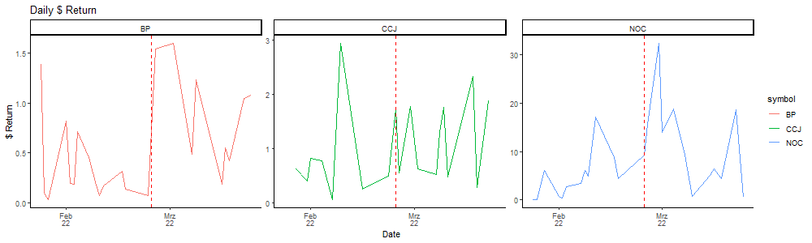

#### Wykres kumulowanej dziennej stopy zwrotu (w dolarach)

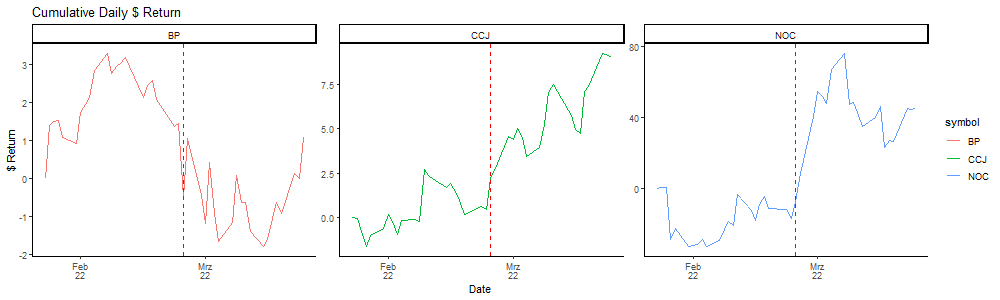

#### Wnioski

Wzrost wartości akcji Northrop Grumman Corporation oraz Cameco związany jest ze wzrostem wartości oferty obu spółek i stosunkowo niewielkim ryzykem inwestycji z perspektywy inwestorów. Innym kluczowym czynnikiem jest brak potrzeby dostosowania się lub zmiany sposobu funkcjonowania tychże spółek w obliczu nowej sytuacji politycznej.

Northrop Grumman Corporation, jako spółka współpracująca z rządem federalnym USA, uważana jest za rozsądną inwestycję. W przypadku długotrwałej wojny w Ukrainie przeznaczanie dużych środków z budżetu federalnego na zapasy broni dla Ukraińców są pewne, a to oznacza stały przychód dla tej spółki.

Dodatkowo, wojna wywołała fundamentalną zmianę postrzegania kwestii bezpieczeńsywa i skutkuje już odczuwalną rewizją polityki obronnej Zachodu, przejawiającą się przede wszytkich znacznym zwiększeniem budżetu obronnego większości krajów zachodnich. Wszystkie te elementy czynią z Northrop Grumman Corporation obiecującą inwestycję.

Cameco od dłuższego czasu osiąga rekordowe zysku z uwagi na napiętą podaż w następstwie pandemii, co doprowadziło do najwyższych od 9 lat cen uranu. Ponadto, sytuacja w Ukrainie skłoniła przywódców całego świata do poszukiwania alternatywnych źródeł energii, co napędza popyt na uran i sprawia, że akcje Cameco wydają się być dobrą inwestycją.

W teorii, British Petroleum powinno notować wzrost z uwagi na handel kluczowym towarem, jaki jest ropa naftowa i jej produkty. W związku ze wzrostem cen ropy naftowej, Rosnieft, w którym BO posiada udziały od ponad dekady, okazał się cennym udziałowcem. British Petroleum postanowiło jendak pozbyć się udziałów w Rosniefcie, co oznacza, że przyłączając się do kampanii izolowania rosyjskiej gospodarki, naraziło się na straty finansowe sięgające 25 mld dolarów. Ten element okazał się być kluczowym dla cen akcji i wyników giełdowych tej spółki.